# Tree Detection with YOLOv12

Github: https://github.com/RSandAI/VHRTrees

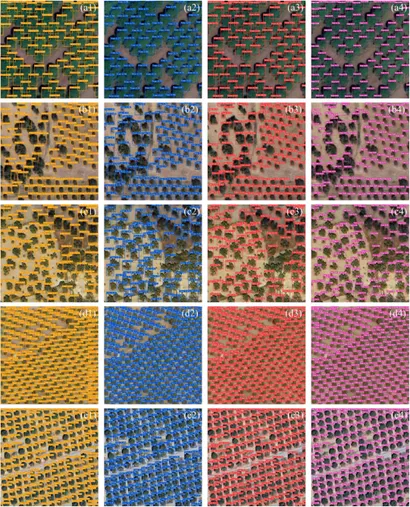

Let's start by connecting the drive

```python
from google.colab import drive
drive.mount('/content/drive')
```

Let's import the libraries and select the paths of the files we're going to use.

```python
import glob
import os
import cv2
import geopandas as gpd
import numpy as np
import pandas as pd
import matplotlib.pyplot as plt
from sklearn.metrics import accuracy_score
from os import mkdir
from skimage.io import imsave
import skimage
```

```python
path_train = '/content/drive/MyDrive/Datasets/VHRTrees_dataset/train'
path_test = '/content/drive/MyDrive/Datasets/VHRTrees_dataset/test'
path_valid = '/content/drive/MyDrive/Datasets/VHRTrees_dataset/validation'
```

We will create a function to import the json with the annotations and convert it into a dataframe:

```python
import json

def create_dataframe(annotation_file):
    with open(annotation_file, 'r') as f:
        data = json.load(f)

    images = data['images']
    annotations = data['annotations']
    categories = data['categories']

    # Create dictionaries for efficient lookup
    image_lookup = {image['id']: image for image in images}
    category_lookup = {category['id']: category['name'] for category in categories}

    rows = []
    for annotation in annotations:
        image_id = annotation['image_id']
        image_info = image_lookup[image_id]

        category_id = annotation['category_id']
        category_name = category_lookup[category_id]

        bbox = annotation['bbox']
        x_min, y_min, width, height = bbox

        rows.append({
            'filename': image_info['file_name'],
            'width': image_info['width'],
            'height': image_info['height'],
            'class': category_name,
            'xmin': x_min,
            'ymin': y_min,
            'xmax': x_min + width,
            'ymax': y_min + height
        })

    df = pd.DataFrame(rows)
    return df
```

```python
train_df = create_dataframe(os.path.join(path_train, '_annotations.coco.json'))
test_df = create_dataframe(os.path.join(path_test, '_annotations.coco.json'))
valid_df = create_dataframe(os.path.join(path_valid, '_annotations.coco.json'))
```

```python
train_df
```

|  | filename | width | height | class | xmin | ymin | xmax | ymax |
| --- | --- | --- | --- | --- | --- | --- | --- | --- |
| 0 | st2_725_image_0_5_jpg.rf.41fc65d1f642b223a3e74... | 256 | 256 | Tree | 0 | 37 | 17.00 | 58.00 |
| 1 | st2_725_image_0_5_jpg.rf.41fc65d1f642b223a3e74... | 256 | 256 | Tree | 155 | 49 | 186.00 | 77.00 |
| 2 | st2_725_image_0_5_jpg.rf.41fc65d1f642b223a3e74... | 256 | 256 | Tree | 179 | 28 | 195.00 | 43.00 |
| 3 | st2_725_image_0_5_jpg.rf.41fc65d1f642b223a3e74... | 256 | 256 | Tree | 203 | 68 | 223.00 | 83.00 |
| 4 | st2_725_image_0_5_jpg.rf.41fc65d1f642b223a3e74... | 256 | 256 | Tree | 139 | 131 | 153.00 | 139.00 |
| ... | ... | ... | ... | ... | ... | ... | ... | ... |
| 60351 | t8_04_08_jpg.rf.ffbd05063ac62d1ca300228da28b8c... | 256 | 256 | Tree | 20 | 1 | 27.50 | 9.75 |
| 60352 | t8_04_08_jpg.rf.ffbd05063ac62d1ca300228da28b8c... | 256 | 256 | Tree | 82 | 150 | 98.00 | 163.25 |
| 60353 | t8_04_08_jpg.rf.ffbd05063ac62d1ca300228da28b8c... | 256 | 256 | Tree | 58 | 60 | 79.50 | 82.75 |
| 60354 | t8_04_08_jpg.rf.ffbd05063ac62d1ca300228da28b8c... | 256 | 256 | Tree | 94 | 184 | 111.78 | 210.67 |
| 60355 | t8_04_08_jpg.rf.ffbd05063ac62d1ca300228da28b8c... | 256 | 256 | Tree | 149 | 122 | 176.41 | 144.22 |

60356 rows × 8 columns

```python
train_image_list = [f for f in os.listdir(path_train) if f.endswith('.jpg')]
test_image_list = [f for f in os.listdir(path_test) if f.endswith('.jpg')]
valid_image_list = [f for f in os.listdir(path_valid) if f.endswith('.jpg')]
```

```python
len(train_image_list)
```

```
1023
```

Now let's plot an example of images with their objects

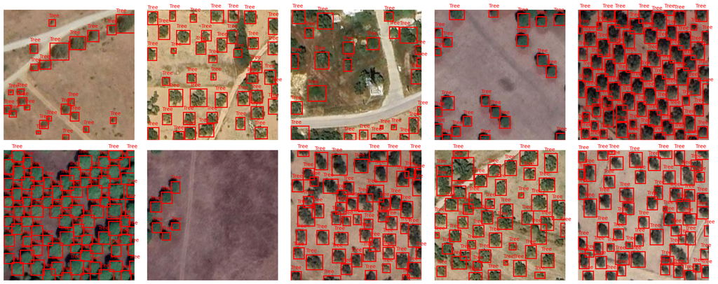

```python
import matplotlib.pyplot as plt
import matplotlib.patches as patches

# Select 10 random images from the training set
num_images_to_plot = 10
image_indices = np.random.choice(len(train_image_list), size=num_images_to_plot, replace=False)

fig, axes = plt.subplots(2, 5, figsize=(20, 8))  # Create a 2x5 grid of subplots

for i, index in enumerate(image_indices):
    image_filename = train_image_list[index]
    image_path = os.path.join(path_train, image_filename)
    image = cv2.imread(image_path)
    image_rgb = cv2.cvtColor(image, cv2.COLOR_BGR2RGB)

    row = i // 5
    col = i % 5
    ax = axes[row, col]
    ax.imshow(image_rgb)

    image_df = train_df[train_df['filename'] == image_filename]

    for _, row in image_df.iterrows():
        xmin = row['xmin']
        ymin = row['ymin']
        xmax = row['xmax']
        ymax = row['ymax']
        width = xmax - xmin
        height = ymax - ymin
        rect = patches.Rectangle((xmin, ymin), width, height, linewidth=2, edgecolor='r', facecolor='none')
        ax.add_patch(rect)
        ax.text(xmin, ymin - 5, row['class'], color='r') # display class label

    ax.axis('off')

plt.tight_layout()
plt.show()
```

We generate the BoundBoxes and add the ID column

```python
train_df['class'] = 0
test_df['class'] = 0
valid_df['class'] = 0
```

```python
train_df['bounds'] = train_df.apply(lambda row: (int(row['xmin']), int(row['ymin']), int(row['xmax']), int(row['ymax'])), axis=1)
valid_df['bounds'] = valid_df.apply(lambda row: (int(row['xmin']), int(row['ymin']), int(row['xmax']), int(row['ymax'])), axis=1)
test_df['bounds'] = test_df.apply(lambda row: (int(row['xmin']), int(row['ymin']), int(row['xmax']), int(row['ymax'])), axis=1)
```

Creation of directories for storing data (images and labels)

```python
!mkdir tree_data
%cd tree_data
```

```
/content/tree_data
```

```python
!mkdir images
!mkdir labels
%cd images
!mkdir train
!mkdir validation
%cd ..
%cd labels
!mkdir train
!mkdir validation
%cd ..
%cd ..
```

```
/content/tree_data/images
/content/tree_data
/content/tree_data/labels
/content/tree_data
/content
```

Let's copy images and labels to the created *folders*, converting to x-center, y-center, x-extend, y-extend and normalizing with the image size:

```python
import numpy as np
import shutil
import ast
import glob
```

```python
INPUT_PATH = '/content/drive/MyDrive/Datasets/VHRTrees_dataset/'
OUTPUT_PATH = '/content/tree_data'
im_size = 256
def process_data(data, data_type='train'):
    for _, row in data.iterrows():
        image_name = os.path.splitext(row['filename'])[0]
        bounding_boxes = row['bboxes'] # Changed to list of tuples
        classes = row['classes']
        yolo_data = []

        for bbox, Class in zip(bounding_boxes, classes):

            x_min = bbox[0]
            y_min = bbox[1]
            x_max = bbox[2]
            y_max = bbox[3]

            x_center = (x_min + x_max) / 2.0 / im_size
            y_center = (y_min + y_max) / 2.0 / im_size
            x_extend = (x_max - x_min) / im_size
            y_extend = (y_max - y_min) / im_size

            yolo_data.append([Class, x_center, y_center, x_extend, y_extend])

        yoy_data = np.array(yolo_data)
        np.savetxt(
            os.path.join(OUTPUT_PATH, f"labels/{data_type}/{image_name}.txt"),
            yolo_data,
            fmt = ["%d", "%f", "%f", "%f", "%f"]
        )
        print(os.path.join(INPUT_PATH, f"{data_type}/{image_name}.jpg"))
        print(os.path.join(OUTPUT_PATH, f"images/{data_type}/{image_name}.jpg"))
        shutil.copyfile(
            os.path.join(INPUT_PATH, f"{data_type}/{image_name}.jpg"),
            os.path.join(OUTPUT_PATH, f"images/{data_type}/{image_name}.jpg")
        )




df_train_group = train_df.groupby('filename')['bounds'].apply(list).reset_index(name='bboxes')
df_train_group['classes'] = train_df.groupby('filename')['class'].apply(list).reset_index(drop=True)

df_valid_group = valid_df.groupby('filename')['bounds'].apply(list).reset_index(name='bboxes')
df_valid_group['classes'] = valid_df.groupby('filename')['class'].apply(list).reset_index(drop=True)

process_data(df_train_group, data_type='train')
process_data(df_valid_group, data_type='validation')
```

[output not shown]

[output cut: 2443 more lines]

[output not shown]

Conversion check:

```python
f = open('/content/tree_data/labels/train/'+os.listdir("/content/tree_data/labels/train/")[3])
print(f.name)
for l in f:
    print(l)
```

```
/content/tree_data/labels/train/a13_01_01_jpg.rf.857a2a3ee3e0be828957cd2b4a08c368.txt
0 0.632812 0.265625 0.062500 0.070312

0 0.576172 0.107422 0.082031 0.113281

0 0.371094 0.214844 0.062500 0.078125

0 0.279297 0.167969 0.082031 0.101562

0 0.205078 0.310547 0.082031 0.160156

0 0.039062 0.312500 0.078125 0.117188

0 0.021484 0.429688 0.042969 0.062500

0 0.128906 0.570312 0.156250 0.171875

0 0.187500 0.486328 0.085938 0.089844

0 0.283203 0.572266 0.074219 0.089844

0 0.314453 0.433594 0.058594 0.093750

0 0.414062 0.505859 0.078125 0.089844

0 0.408203 0.332031 0.066406 0.070312

0 0.525391 0.410156 0.105469 0.156250

0 0.673828 0.427734 0.097656 0.152344

0 0.775391 0.500000 0.074219 0.093750

0 0.830078 0.410156 0.066406 0.085938

0 0.867188 0.525391 0.070312 0.105469

0 0.925781 0.427734 0.070312 0.082031

0 0.958984 0.544922 0.066406 0.066406
```

[output cut: 69 more lines]

```
0 0.578125 0.599609 0.046875 0.058594

0 0.513672 0.542969 0.066406 0.062500

0 0.480469 0.101562 0.085938 0.085938

0 0.560547 0.257812 0.074219 0.070312

0 0.388672 0.763672 0.042969 0.042969

0 0.574219 0.847656 0.062500 0.054688

0 0.476562 0.703125 0.117188 0.195312

0 0.742188 0.269531 0.078125 0.140625
```

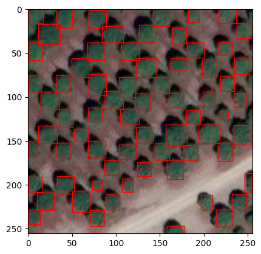

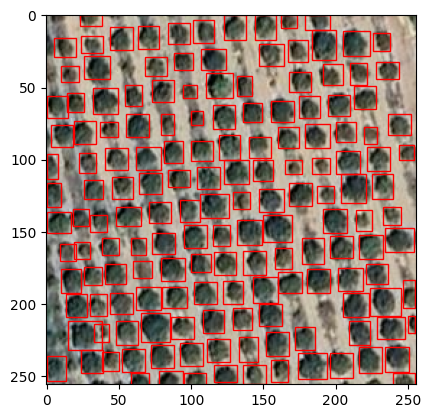

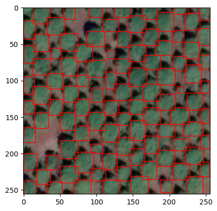

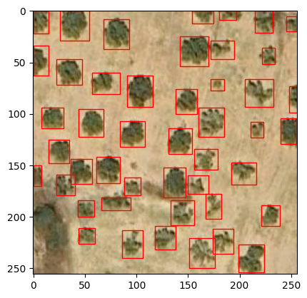

```python
import matplotlib.pyplot as plt
import matplotlib.patches as patches
from PIL import Image

def plot_image_with_boxes_from_txt(image_path, txt_path):
    try:
        img = Image.open(image_path)
        fig, ax = plt.subplots(1)
        ax.imshow(img)

        with open(txt_path, 'r') as file:
            for line in file:
                parts = line.strip().split()
                if len(parts) >= 5:  # Ensure enough elements
                    class_id = int(parts[0])
                    x_center = float(parts[1])
                    y_center = float(parts[2])
                    width = float(parts[3])
                    height = float(parts[4])

                    image_width, image_height = img.size

                    xmin = int((x_center - width / 2) * image_width)
                    ymin = int((y_center - height / 2) * image_height)
                    xmax = int((x_center + width / 2) * image_width)
                    ymax = int((y_center + height / 2) * image_height)

                    width = xmax - xmin
                    height = ymax - ymin

                    rect = patches.Rectangle((xmin, ymin), width, height, linewidth=1, edgecolor='r', facecolor='none')
                    ax.add_patch(rect)

        plt.show()
    except FileNotFoundError:
        print(f"Error: Image or text file not found at {image_path} or {txt_path}")
    except Exception as e:
        print(f"An error occurred: {e}")


# Example usage (replace with your actual paths)
# Make sure that corresponding image and text files exist.
image_folder = "/content/tree_data/images/train" #update to your path
txt_folder = "/content/tree_data/labels/train" #update to your path

image_files = [f for f in os.listdir(image_folder) if f.endswith(('.png', '.jpg', '.jpeg'))]

for image_file in image_files[0:4]:
    image_path = os.path.join(image_folder, image_file)
    txt_file = image_file[:-4] + ".txt"  # Assuming txt file has same name as image
    txt_path = os.path.join(txt_folder, txt_file)
    plot_image_with_boxes_from_txt(image_path, txt_path)
```

We create the YAML file with the image paths

```python
%%writefile tree_detection.yaml

train: /content/tree_data/images/train
val: /content/tree_data/images/validation
nc: 1
names: ['Tree']
```

```
Writing tree_detection.yaml
```

Let's clone YOLOv12's github and install the Ultralyltics library

```python
!git clone https://github.com/sunsmarterjie/yolov12
%cd yolov12
```

```
Cloning into 'yolov12'...
remote: Enumerating objects: 814, done.
remote: Counting objects: 100% (107/107), done.
remote: Compressing objects: 100% (96/96), done.
remote: Total 814 (delta 58), reused 19 (delta 11), pack-reused 707 (from 2)
Receiving objects: 100% (814/814), 1.47 MiB | 12.63 MiB/s, done.
Resolving deltas: 100% (348/348), done.
/content/yolov12
```

```python
!pip install ultralytics

from IPython import display

import ultralytics
ultralytics.checks()
```

```
Ultralytics 8.3.63 🚀 Python-3.11.11 torch-2.5.1+cu124 CUDA:0 (Tesla T4, 15095MiB)
Setup complete ✅ (2 CPUs, 12.7 GB RAM, 33.3/235.7 GB disk)
```

```python
from ultralytics import YOLO
```

```python
import os
HOME = os.getcwd()
print(HOME)
```

```
/content/yolov12
```

We can start training for 200 epochs

```python
%cd {HOME}

!yolo task=detect mode=train model=yolo12x.pt  data=/content/tree_detection.yaml epochs=200 imgsz=256
```

```
/content/yolov12
Creating new Ultralytics Settings v0.0.6 file ✅
View Ultralytics Settings with 'yolo settings' or at '/root/.config/Ultralytics/settings.json'
Update Settings with 'yolo settings key=value', i.e. 'yolo settings runs_dir=path/to/dir'. For help see https://docs.ultralytics.com/quickstart/#ultralytics-settings.
Downloading https://github.com/ultralytics/assets/releases/download/v8.3.0/yolo12x.pt to 'yolo12x.pt'...
100% 114M/114M [00:00<00:00, 266MB/s]
Ultralytics 8.3.78 🚀 Python-3.11.11 torch-2.5.1+cu124 CUDA:0 (Tesla T4, 15095MiB)
engine/trainer: task=detect, mode=train, model=yolo12x.pt, data=/content/tree_detection.yaml, epochs=200, time=None, patience=100, batch=16, imgsz=256, save=True, save_period=-1, cache=False, device=None, workers=8, project=None, name=train, exist_ok=False, pretrained=True, optimizer=auto, verbose=T…
Downloading https://ultralytics.com/assets/Arial.ttf to '/root/.config/Ultralytics/Arial.ttf'...
100% 755k/755k [00:00<00:00, 14.6MB/s]
WARNING: All log messages before absl::InitializeLog() is called are written to STDERR
E0000 00:00:1740147662.028750    3917 cuda_dnn.cc:8310] Unable to register cuDNN factory: Attempting to register factory for plugin cuDNN when one has already been registered
E0000 00:00:1740147662.122700    3917 cuda_blas.cc:1418] Unable to register cuBLAS factory: Attempting to register factory for plugin cuBLAS when one has already been registered
Overriding model.yaml nc=80 with nc=1

                   from  n    params  module                                       arguments
  0                  -1  1      2784  ultralytics.nn.modules.conv.Conv             [3, 96, 3, 2]
  1                  -1  1    166272  ultralytics.nn.modules.conv.Conv             [96, 192, 3, 2]
  2                  -1  2    389760  ultralytics.nn.modules.block.C3k2            [192, 384, 2, True, 0.25]
  3                  -1  1   1327872  ultralytics.nn.modules.conv.Conv             [384, 384, 3, 2]
  4                  -1  2   1553664  ultralytics.nn.modules.block.C3k2            [384, 768, 2, True, 0.25]
  5                  -1  1   5309952  ultralytics.nn.modules.conv.Conv             [768, 768, 3, 2]
  6                  -1  4   9512128  ultralytics.nn.modules.block.A2C2f           [768, 768, 4, True, 4, True, 1.2]
  7                  -1  1   5309952  ultralytics.nn.modules.conv.Conv             [768, 768, 3, 2]
  8                  -1  4   9512128  ultralytics.nn.modules.block.A2C2f           [768, 768, 4, True, 1, True, 1.2]
  9                  -1  1         0  torch.nn.modules.upsampling.Upsample         [None, 2, 'nearest']
 10             [-1, 6]  1         0  ultralytics.nn.modules.conv.Concat           [1]
 11                  -1  2   4727040  ultralytics.nn.modules.block.A2C2f           [1536, 768, 2, False, -1, True, 1.2]
 12                  -1  1         0  torch.nn.modules.upsampling.Upsample         [None, 2, 'nearest']
 13             [-1, 4]  1         0  ultralytics.nn.modules.conv.Concat           [1]
 14                  -1  2   1331328  ultralytics.nn.modules.block.A2C2f           [1536, 384, 2, False, -1, True, 1.2]
 15                  -1  1   1327872  ultralytics.nn.modules.conv.Conv             [384, 384, 3, 2]
 16            [-1, 11]  1         0  ultralytics.nn.modules.conv.Concat           [1]
 17                  -1  2   4579584  ultralytics.nn.modules.block.A2C2f           [1152, 768, 2, False, -1, True, 1.2]
 18                  -1  1   5309952  ultralytics.nn.modules.conv.Conv             [768, 768, 3, 2]
 19             [-1, 8]  1         0  ultralytics.nn.modules.conv.Concat           [1]
 20                  -1  2   5612544  ultralytics.nn.modules.block.C3k2            [1536, 768, 2, True]
 21        [14, 17, 20]  1   3146707  ultralytics.nn.modules.head.Detect           [1, [384, 768, 768]]
YOLOv12x summary: 488 layers, 59,119,539 parameters, 59,119,523 gradients, 199.8 GFLOPs

```

[output cut: 1021 more lines]

```
                 Class     Images  Instances      Box(P          R      mAP50  mAP50-95): 100% 8/8 [00:02<00:00,  3.23it/s]
                   all        226      13227      0.947      0.955      0.976      0.626

200 epochs completed in 1.719 hours.
Optimizer stripped from runs/detect/train/weights/last.pt, 119.1MB
Optimizer stripped from runs/detect/train/weights/best.pt, 119.1MB

Validating runs/detect/train/weights/best.pt...
Ultralytics 8.3.78 🚀 Python-3.11.11 torch-2.5.1+cu124 CUDA:0 (Tesla T4, 15095MiB)
YOLOv12x summary (fused): 283 layers, 59,044,499 parameters, 0 gradients, 198.5 GFLOPs
                 Class     Images  Instances      Box(P          R      mAP50  mAP50-95): 100% 8/8 [00:07<00:00,  1.00it/s]
                   all        226      13227      0.952       0.95      0.978      0.628
Speed: 0.1ms preprocess, 10.8ms inference, 0.0ms loss, 10.9ms postprocess per image
Results saved to runs/detect/train
💡 Learn more at https://docs.ultralytics.com/modes/train
```

Analysis of results (Confusion matrix and metrics)

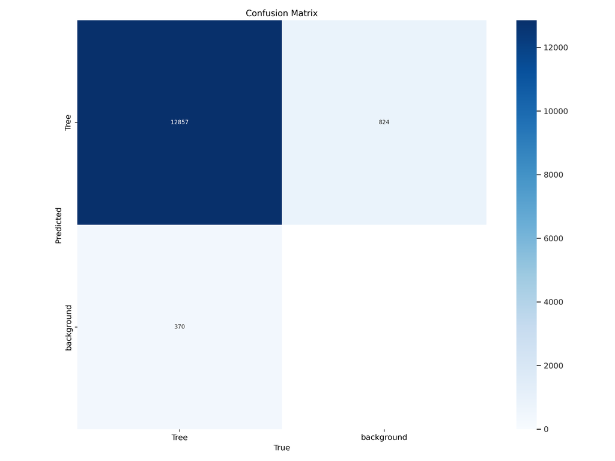

```python
from IPython.display import display, Image
Image(filename=f'{HOME}/runs/detect/train/confusion_matrix.png', width=600)
```

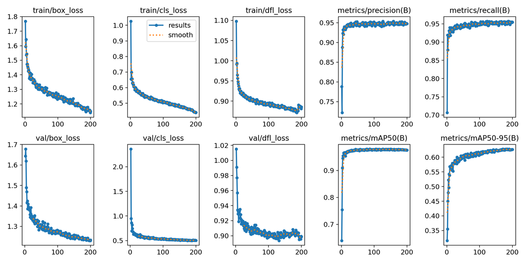

```python
Image(filename=f'{HOME}/runs/detect/train/results.png', width=600)
```

Applying the prediction to the validation images:

```python
!yolo task=detect mode=predict model=/content/yolov12/runs/detect/train/weights/best.pt conf=0.30 source= /content/tree_data/images/validation save=true save_txt=true
```

```
Ultralytics 8.3.78 🚀 Python-3.11.11 torch-2.5.1+cu124 CUDA:0 (Tesla T4, 15095MiB)
YOLOv12x summary (fused): 283 layers, 59,044,499 parameters, 0 gradients, 198.5 GFLOPs

image 1/226 /content/tree_data/images/validation/43_SA_04_04_jpg.rf.80c9eb91d06689d3f80b5d482d81d0b2.jpg: 256x256 58 Trees, 35.2ms
image 2/226 /content/tree_data/images/validation/43_SA_05_04_jpg.rf.bd5765d84c7467f6a65f34ae6e517959.jpg: 256x256 42 Trees, 29.8ms
image 3/226 /content/tree_data/images/validation/46_SA_02_01_jpg.rf.68170e84139dc504d8e44e1e10a3e0bc.jpg: 256x256 50 Trees, 29.7ms
image 4/226 /content/tree_data/images/validation/46_SA_04_04_png_jpg.rf.eac3bd74bdaf60220647c56a9c5d53c6.jpg: 256x256 88 Trees, 30.9ms
image 5/226 /content/tree_data/images/validation/46_SA_04_05_jpg.rf.2852620073f207f08575ac7748bbfdb2.jpg: 256x256 84 Trees, 27.3ms
image 6/226 /content/tree_data/images/validation/46_SA_04_08_jpg.rf.c8dd5506bacd5bd32c5ebd4fdb1c9290.jpg: 256x256 64 Trees, 27.2ms
image 7/226 /content/tree_data/images/validation/46_SA_05_06_png_jpg.rf.71280b8b0ef588c811cc4a1913640578.jpg: 256x256 97 Trees, 27.3ms
image 8/226 /content/tree_data/images/validation/a10_01_02_jpg.rf.5d520965be3e378b7711e042f20cf652.jpg: 256x256 42 Trees, 29.0ms
image 9/226 /content/tree_data/images/validation/a10_02_06_jpg.rf.c193a58f54f5d90cffe854694f917c5a.jpg: 256x256 103 Trees, 26.9ms
image 10/226 /content/tree_data/images/validation/a10_03_01_jpg.rf.f6f3544cabf850adc2690d35b928bded.jpg: 256x256 58 Trees, 27.2ms
image 11/226 /content/tree_data/images/validation/a10_03_06_jpg.rf.0fd7e515a1dcfe150177eb867e6e5ad1.jpg: 256x256 37 Trees, 28.7ms
image 12/226 /content/tree_data/images/validation/a10_05_01_jpg.rf.3dd2538c32488cc9f72dc0b8fb9e4287.jpg: 256x256 32 Trees, 27.0ms
image 13/226 /content/tree_data/images/validation/a13_01_03_jpg.rf.87c9e4f81c9a2f3630e862437220e569.jpg: 256x256 65 Trees, 26.4ms
image 14/226 /content/tree_data/images/validation/a13_04_02_jpg.rf.a0e6a72cf6399bab673b0690d11375e4.jpg: 256x256 42 Trees, 26.5ms
image 15/226 /content/tree_data/images/validation/a13_04_05_jpg.rf.7d80221e09514f770ad7c2be96cd44aa.jpg: 256x256 55 Trees, 27.2ms
image 16/226 /content/tree_data/images/validation/a13_05_01_jpg.rf.84567cffcc29bfe757776823823fa8fa.jpg: 256x256 70 Trees, 40.1ms
image 17/226 /content/tree_data/images/validation/a13_05_02_jpg.rf.972290a3a590c39ba06a40479342daae.jpg: 256x256 51 Trees, 28.0ms
image 18/226 /content/tree_data/images/validation/a13_05_04_jpg.rf.be1940fdee9b41fe341145d2e48bcd80.jpg: 256x256 57 Trees, 29.2ms
image 19/226 /content/tree_data/images/validation/a16_01_08_jpg.rf.47ec17a425e594ded2c089b544448f52.jpg: 256x256 64 Trees, 26.2ms
image 20/226 /content/tree_data/images/validation/a4_01_03_jpg.rf.2de768a218b21dd9368e4d969f30abd9.jpg: 256x256 72 Trees, 26.3ms
image 21/226 /content/tree_data/images/validation/a4_03_04_jpg.rf.b276f813d6d2145b4af1f878cd32a4b7.jpg: 256x256 76 Trees, 26.0ms
image 22/226 /content/tree_data/images/validation/a4_03_07_jpg.rf.7adf3847c26ca5c93d04999177ee38ca.jpg: 256x256 56 Trees, 26.3ms
image 23/226 /content/tree_data/images/validation/a5_02_01_jpg.rf.900ca050acaebee6c7a2a400cbddc70e.jpg: 256x256 70 Trees, 31.2ms
image 24/226 /content/tree_data/images/validation/a5_04_01_jpg.rf.5b577f1f4ef71bc76aab8480844b2b1f.jpg: 256x256 55 Trees, 27.0ms
image 25/226 /content/tree_data/images/validation/a5_04_09_jpg.rf.8e23d833ae100a4fc6e140e72d875745.jpg: 256x256 67 Trees, 26.3ms
image 26/226 /content/tree_data/images/validation/a5_05_05_jpg.rf.ca1dec90883c5fd9bfa3fb3fee39cae0.jpg: 256x256 83 Trees, 26.4ms
image 27/226 /content/tree_data/images/validation/b11_01_03_jpg.rf.925d254fb86f3b607d839b1ce52b97f1.jpg: 256x256 177 Trees, 26.5ms
image 28/226 /content/tree_data/images/validation/b11_02_05_png.rf.aec32cf0bf230373f3e284d5f7c3bec9.jpg: 256x256 165 Trees, 27.0ms
image 29/226 /content/tree_data/images/validation/b11_03_04_jpg.rf.07fc6713c3347a4da31448cc8969369a.jpg: 256x256 163 Trees, 33.3ms
image 30/226 /content/tree_data/images/validation/b11_04_04_png.rf.96b03c6d2a483aefa3e101b7563a4a6b.jpg: 256x256 173 Trees, 26.5ms
image 31/226 /content/tree_data/images/validation/b11_05_07_jpg.rf.56ed7c139ab248934f4bf3c9a3317ce5.jpg: 256x256 132 Trees, 28.4ms
image 32/226 /content/tree_data/images/validation/b12_01_03_jpg.rf.52c0fd5fede361a9e6c7045488777ab3.jpg: 256x256 167 Trees, 26.6ms
image 33/226 /content/tree_data/images/validation/b12_01_05_jpg.rf.a91ccf9c8e971ca818e49af26230c3d7.jpg: 256x256 155 Trees, 28.3ms
image 34/226 /content/tree_data/images/validation/b12_02_05_jpg.rf.e13e66db34cc96443c6880cbaa18cc60.jpg: 256x256 156 Trees, 27.1ms
image 35/226 /content/tree_data/images/validation/b12_04_03_png_jpg.rf.d75ef51cdb6e5270b2576dc11f8b1862.jpg: 256x256 158 Trees, 28.9ms
image 36/226 /content/tree_data/images/validation/b13_02_05_jpg.rf.a0f6e33a182d4bc6a83ef03081b26d8c.jpg: 256x256 171 Trees, 27.2ms
image 37/226 /content/tree_data/images/validation/b13_03_04_png_jpg.rf.56cc1f3c1d5d42e6e2b8e643f83ecd6e.jpg: 256x256 157 Trees, 36.8ms
```

[output cut: 178 more lines]

```
image 216/226 /content/tree_data/images/validation/y7_1233_image_3_3_jpg.rf.03faa23eff0452a10f56c2881dd1a45d.jpg: 256x256 48 Trees, 26.4ms
image 217/226 /content/tree_data/images/validation/y7_1245_image_4_5_jpg.rf.1fd42a9e105c5d715120ec2e5346881a.jpg: 256x256 49 Trees, 25.3ms
image 218/226 /content/tree_data/images/validation/y7_1249_image_4_9_jpg.rf.adf0460ea6454d4fe643f3bc9939308d.jpg: 256x256 31 Trees, 25.0ms
image 219/226 /content/tree_data/images/validation/y8_1271_image_1_1_jpg.rf.fe8dafda5c1e5e1783d535c037cda932.jpg: 256x256 58 Trees, 24.8ms
image 220/226 /content/tree_data/images/validation/y8_1275_image_1_5_jpg.rf.6f6d85f918a40745fb49414312728347.jpg: 256x256 66 Trees, 25.6ms
image 221/226 /content/tree_data/images/validation/y8_1277_image_1_7_jpg.rf.5c4b4b064504b1cfcd7e0f27b8b0ef1f.jpg: 256x256 46 Trees, 27.1ms
image 222/226 /content/tree_data/images/validation/y8_1281_image_2_1_jpg.rf.b01a33c91834b4eca2e4646504c340eb.jpg: 256x256 55 Trees, 25.0ms
image 223/226 /content/tree_data/images/validation/y8_1305_image_4_5_jpg.rf.cf41bc9e84e02be207ba96eb0fb105fe.jpg: 256x256 40 Trees, 25.1ms
image 224/226 /content/tree_data/images/validation/y9_1371_image_5_1_jpg.rf.2cb17e9704752e1abed748b0f6ca56bc.jpg: 256x256 34 Trees, 25.3ms
image 225/226 /content/tree_data/images/validation/y9_1376_image_5_6_jpg.rf.1eddee2cb6da5b3ec0d1b8315799453f.jpg: 256x256 34 Trees, 25.8ms
image 226/226 /content/tree_data/images/validation/y9_1378_image_5_8_jpg.rf.78da21de8d8a58be3925567b83ffeef4.jpg: 256x256 35 Trees, 25.1ms
Speed: 0.5ms preprocess, 29.3ms inference, 3.0ms postprocess per image at shape (1, 3, 256, 256)
Results saved to runs/detect/predict
226 labels saved to runs/detect/predict/labels
💡 Learn more at https://docs.ultralytics.com/modes/predict
```

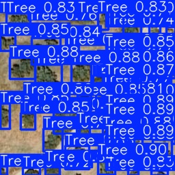

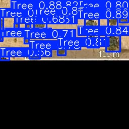

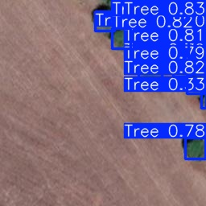

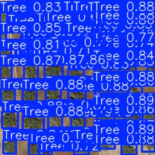

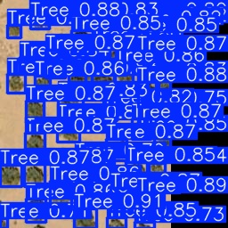

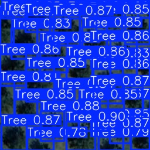

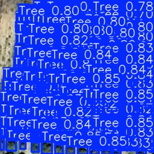

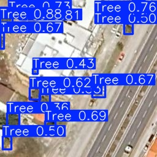

```python
for image_path in glob.glob(f'{HOME}/runs/detect/predict/*.jpg')[:8]:
      display(Image(filename=image_path, height=400))
      print("\n")
```

Generation of the dataframe with the resulting bounds from the predicted images:

```python
from skimage import io

df_full = pd.DataFrame([])
imgs_to_pred = [f for f in os.listdir('/content/yolov12/runs/detect/predict/labels/') if f.endswith('.txt')]
for images in imgs_to_pred:
  filename = os.path.splitext(images)[0]
  path = f'/content/yolov12/runs/detect/predict/labels/'+filename+'.txt'
  cols = ['class', 'x-center', 'y-center', 'x_extend', 'y_extend']
  df = pd.read_csv(path, sep=" ", header=None)
  df.columns = cols
  df['x-center'] = np.round(df['x-center'] * im_size)
  df['y-center'] = np.round(df['y-center'] * im_size)
  df['x_extend'] = np.round(df['x_extend'] * im_size)
  df['y_extend'] = np.round(df['y_extend'] * im_size)
  df['image_filename'] = filename
  df_full = pd.concat([df_full, df])
```

```python
df_full
```

|  | class | x-center | y-center | x_extend | y_extend | image_filename |
| --- | --- | --- | --- | --- | --- | --- |
| 0 | 0 | 189.0 | 114.0 | 10.0 | 11.0 | st2_727_image_0_7_jpg.rf.ffec547e479bf00bf8c94... |
| 1 | 0 | 146.0 | 131.0 | 12.0 | 12.0 | st2_727_image_0_7_jpg.rf.ffec547e479bf00bf8c94... |
| 2 | 0 | 242.0 | 11.0 | 12.0 | 12.0 | st2_727_image_0_7_jpg.rf.ffec547e479bf00bf8c94... |
| 3 | 0 | 178.0 | 166.0 | 10.0 | 10.0 | st2_727_image_0_7_jpg.rf.ffec547e479bf00bf8c94... |
| 4 | 0 | 250.0 | 106.0 | 11.0 | 10.0 | st2_727_image_0_7_jpg.rf.ffec547e479bf00bf8c94... |
| ... | ... | ... | ... | ... | ... | ... |
| 17 | 0 | 37.0 | 195.0 | 17.0 | 17.0 | sa24_406_image_4_6_jpg.rf.1eef76fafc641fce23a4... |
| 18 | 0 | 56.0 | 24.0 | 16.0 | 16.0 | sa24_406_image_4_6_jpg.rf.1eef76fafc641fce23a4... |
| 19 | 0 | 55.0 | 175.0 | 14.0 | 14.0 | sa24_406_image_4_6_jpg.rf.1eef76fafc641fce23a4... |
| 20 | 0 | 37.0 | 6.0 | 11.0 | 12.0 | sa24_406_image_4_6_jpg.rf.1eef76fafc641fce23a4... |
| 21 | 0 | 38.0 | 158.0 | 12.0 | 12.0 | sa24_406_image_4_6_jpg.rf.1eef76fafc641fce23a4... |

13909 rows × 6 columns

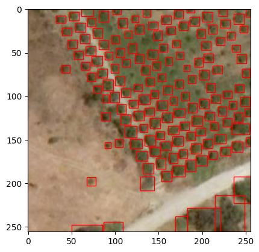

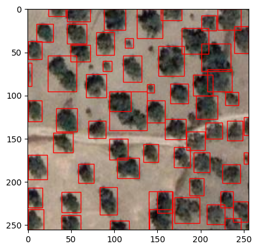

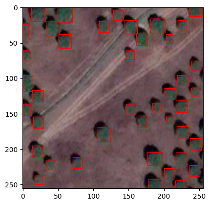

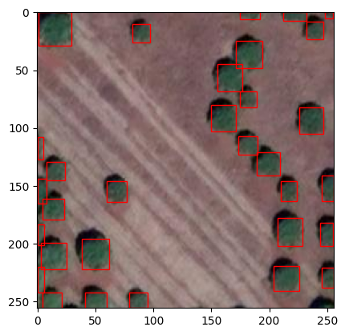

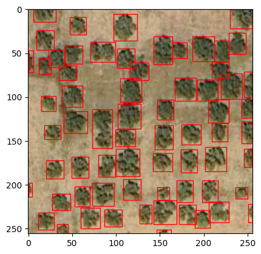

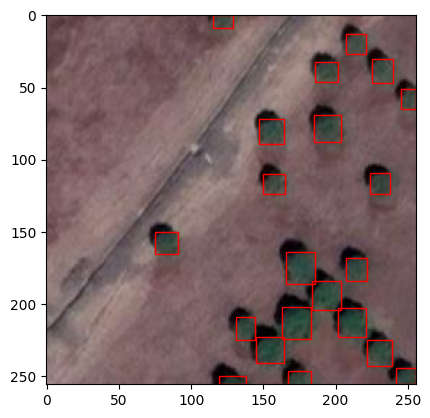

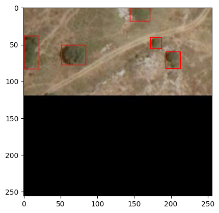

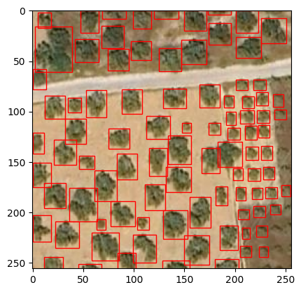

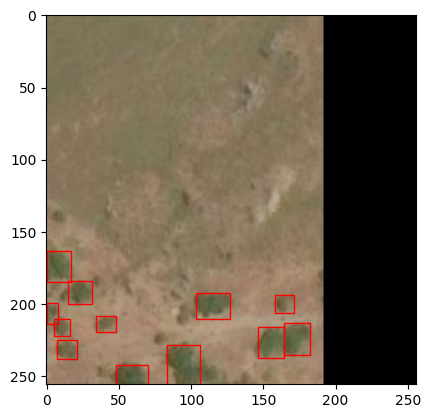

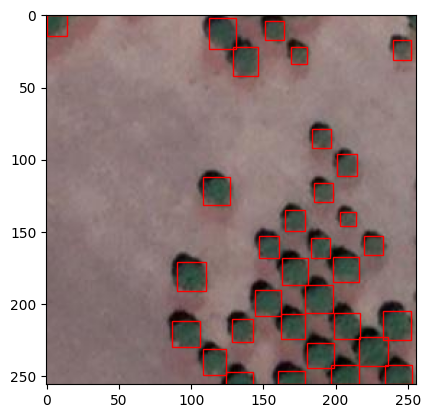

```python
import matplotlib.pyplot as plt
import matplotlib.patches as patches
from PIL import Image
import os


def plot_image_with_predictions(df, image_folder, num_images=10):
    image_files = df['image_filename'].unique()[:num_images]  # Select unique image filenames

    for image_file in image_files:
        try:
            image_path = os.path.join(image_folder, image_file + ".jpg") # Adjust the file extension if needed
            img = Image.open(image_path)
            fig, ax = plt.subplots(1)
            ax.imshow(img)

            # Filter the dataframe for the current image
            image_df = df[df['image_filename'] == image_file]

            for _, row in image_df.iterrows():
                x_center = row['x-center']
                y_center = row['y-center']
                width = row['x_extend']
                height = row['y_extend']

                xmin = int(x_center - width / 2)
                ymin = int(y_center - height / 2)
                xmax = int(x_center + width / 2)
                ymax = int(y_center + height / 2)

                width = xmax - xmin
                height = ymax - ymin

                rect = patches.Rectangle((xmin, ymin), width, height, linewidth=1, edgecolor='r', facecolor='none')
                ax.add_patch(rect)

            plt.show()
        except FileNotFoundError:
            print(f"Error: Image file not found at {image_path}")
        except Exception as e:
            print(f"An error occurred: {e}")



image_folder = "/content/tree_data/images/validation"  # Replace with the actual folder path
plot_image_with_predictions(df_full, image_folder)
```